# Lab 3 Extra Credit: Spotify

SOC 325: Quantified-Self

2023-11-06

## Preamble before starting the labs

All of the R and RMarkdown files of the lab files for this class are in [github](https://github.com/zalmquist/soc325Rlab). However, PythonHub will have them all pre-installed.

# Getting started: Editing and running code

There are several ways we can run code:

- Highlight lines in the editor window and click **Run** at the top or hit `Ctrl` + `Enter` or `CMD` + `Enter` (Mac) to run them all.
- With your caret on a line you want to run, hit `Ctrl` + `Enter` or `CMD` + `Enter` (Mac). Note your caret moves to the next line, so you can run code sequentially with repeated presses.
- Type individual lines in the console and press enter.
- In R Markdown documents, click within a code chunk and click the green arrow to run the chunk. The button beside that runs all prior chunks.

# Spotify!

This does not work on JupyterHub unfortunately. You have to do this on R and Rstudio on your home computer. I will review it in class, but the lab exercise is extra credit! It is a bit of work to get up and running, but it can be fun to play with your spotify data.

# Load Libraries Needed For this Lab

```r
## Run this code, to manage packages and install as needed.
# Install pacman
if (!require("pacman")) install.packages("pacman", repos = "http://cran.us.r-project.org")
# p_load function loads packages if installed, or install then loads otherwise
pacman::p_load(jsonlite, ggmap,ggplot2, lubridate, zoo,here,tidyverse,kableExtra,ggmap,spotifyr,ggjoy)
```

## Spotify API Access

- See this tutorial for how to acces the API - [spotify R API](https://www.rcharlie.com/spotifyr/).
  - Go to https://developer.spotify.com/dashboard/
  - Log In and accept terms and conditions
  - Create a new app and follow directions on [spotify R API](https://www.rcharlie.com/spotifyr/)

**Based on Solution by Angela Statler – Big Shout out!!**

```r
myclientid<-'YOURCLIENTID'
myclientsecret<-'YOURCLIENTSECRET'



Sys.setenv(SPOTIFY_CLIENT_ID=myclientid)
Sys.setenv(SPOTIFY_CLIENT_SECRET=myclientsecret)

access_token <- get_spotify_authorization_code(scope = c('user-top-read',
                                                         'user-read-recently-played',
                                                         'user-read-private',
                                                         'user-library-read',
                                                        'user-read-email',
                                                        'user-read-playback-state',
                                                        'user-modify-playback-state'))
```

```r
########
## If you run the above code and this code
## You wont save your id in Markdown
########
grp<-get_my_recently_played(limit = 5,
                    authorization = get_spotify_authorization_code(scope = c('user-read-recently-played')))

gta_st <- get_my_top_artists_or_tracks(
  type = "artists",
  limit = 5,
  time_range = "short_term",
  authorization = get_spotify_authorization_code(scope = c('user-top-read')))

gta_lt <- get_my_top_artists_or_tracks(
  type = "artists",
  limit = 5,
  time_range = "long_term",
   authorization = get_spotify_authorization_code(scope = c('user-top-read')))

gta_st_tracks <- get_my_top_artists_or_tracks(
  type = "tracks",
  limit = 5,
  time_range = "short_term",
   authorization = get_spotify_authorization_code(scope = c('user-top-read')))

 gta_lt_tracks <- get_my_top_artists_or_tracks(
   type = "tracks",
   limit = 5,
   time_range = "long_term",
      authorization = get_spotify_authorization_code(scope = c('user-top-read')))
ed <- spotifyr::get_artist_audio_features('ed sheeran')

save(grp,gta_st,gta_lt,gta_st_tracks,gta_lt_tracks,ed,file="data/spotify.Rda")
```

```r
################
## Code Examples
################
## Load example data
load(here("data","spotify.Rda"))


grp%>%
  mutate(artist.name = map_chr(track.artists, function(x) x$name[1]),
         played_at = as_datetime(played_at)) %>%
  select(track.name, artist.name, track.album.name, played_at) %>%
  kable()
```

| track.name | artist.name | track.album.name | played_at |
| --- | --- | --- | --- |
| We Found Love | Rihanna | Talk That Talk | 2023-11-07 01:50:29 |
| Good Feeling | Flo Rida | Wild Ones | 2023-11-07 01:47:05 |
| California Gurls | Katy Perry | Teenage Dream: The Complete Confection | 2023-11-07 01:43:24 |
| Hold My Hand | Jess Glynne | Hold My Hand | 2023-11-07 01:39:42 |
| Good Time | Owl City | The Midsummer Station | 2023-11-07 01:25:58 |

```r
grp %>%
  mutate(artist.name = map_chr(track.artists, function(x) x$name[1]),
         played_at = as_datetime(played_at)) %>%
  select(track.name, artist.name, track.album.name, played_at) %>%
  kable()
```

| track.name | artist.name | track.album.name | played_at |
| --- | --- | --- | --- |
| We Found Love | Rihanna | Talk That Talk | 2023-11-07 01:50:29 |
| Good Feeling | Flo Rida | Wild Ones | 2023-11-07 01:47:05 |
| California Gurls | Katy Perry | Teenage Dream: The Complete Confection | 2023-11-07 01:43:24 |
| Hold My Hand | Jess Glynne | Hold My Hand | 2023-11-07 01:39:42 |
| Good Time | Owl City | The Midsummer Station | 2023-11-07 01:25:58 |

```r
gta_st %>%
  mutate(artist.name = name,genre=map_chr(genres, function(x) x[1])) %>%
  select(artist.name,genre) %>%
  kable()
```

| artist.name | genre |
| --- | --- |
| Taylor Swift | pop |
| Sublime | rap rock |
| Pearl Jam | alternative metal |
| Katy Perry | pop |
| Mat Kearney | acoustic pop |

```r
gta_lt%>%
  select(name, genres) %>%
  rowwise %>%
  mutate(genres = paste(genres, collapse = ', ')) %>%
  ungroup %>%
  kable()
```

| name | genres |
| --- | --- |
| Raffi | canadian children’s music, children’s folk, children’s music |
| Barenaked Ladies | canadian pop, canadian rock, pop rock, post-grunge |
| Ed Sheeran | pop, singer-songwriter pop, uk pop |
| O.A.R. | neo mellow, pop rock |
| George Ezra | folk-pop, neo-singer-songwriter, talent show |

```r
gta_st_tracks %>%
  mutate(artist.name = map_chr(artists, function(x) x$name[1])) %>%
  select(name, artist.name, album.name) %>%
  kable()
```

| name | artist.name | album.name |
| --- | --- | --- |
| Coming Home (Oregon) | Mat Kearney | JUST KIDS (Deluxe Edition) |
| Not for You - Remastered | Pearl Jam | Vitalogy |
| Garden Grove | Sublime | Sublime |
| All Is Found | Evan Rachel Wood | Frozen 2 (Original Motion Picture Soundtrack/Deluxe Edition) |
| One Less Day (Dying Young) | Rob Thomas | Chip Tooth Smile |

```r
ed %>%arrange(-valence) %>%
  select(track_name, valence) %>%
  distinct() %>%
  head(5) %>%
  kable()
```

| track_name | valence |
| --- | --- |
| Sing | 0.939 |
| Shape of You | 0.931 |
| You Need Me, I Don’t Need You | 0.927 |
| Amazing - Live from Kia’s Living Room | 0.925 |
| Eraser | 0.914 |

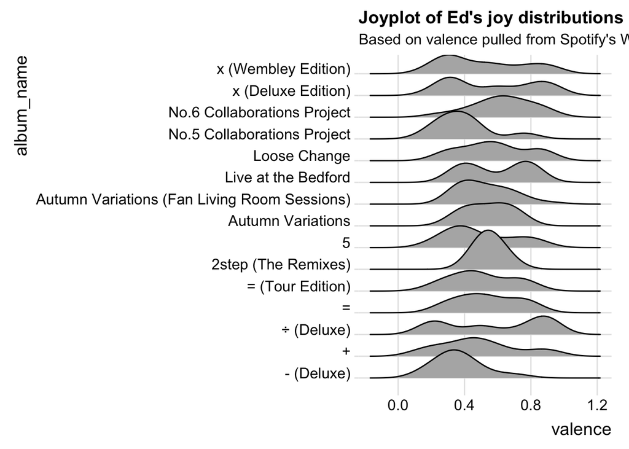

```r
ggplot(ed, aes(x = valence, y = album_name)) +
  geom_joy() +
  theme_joy() +
  ggtitle("Joyplot of Ed's joy distributions",
          subtitle = "Based on valence pulled from Spotify's Web API with spotifyr")
```